# R Notebook

### 5.1 Threshold Sensitivity Test

```r
# common grid that covers W3, W5 and W10

velocity_threshold_grid <- c(-5, -10, -15, -20, -25, -30, -40, -50, -60)
```

We can use the existing threshold sensitivity function:

```r
# CADIA FAILED
cadia_F_vel_w3_thresh <- run_threshold_sensitivity(
  cadia_F_vel_w3,
  velocity_threshold_grid
)

cadia_F_vel_w5_thresh <- run_threshold_sensitivity(
  cadia_F_vel_w5,
  velocity_threshold_grid
)

cadia_F_vel_w10_thresh <- run_threshold_sensitivity(
  cadia_F_vel_w10,
  velocity_threshold_grid
)


# CADIA UNFAILED
cadia_S_vel_w3_thresh <- run_threshold_sensitivity(
  cadia_S_vel_w3,
  velocity_threshold_grid
)

cadia_S_vel_w5_thresh <- run_threshold_sensitivity(
  cadia_S_vel_w5,
  velocity_threshold_grid
)

cadia_S_vel_w10_thresh <- run_threshold_sensitivity(
  cadia_S_vel_w10,
  velocity_threshold_grid
)


# PERU FAILED
peru_F_vel_w3_thresh <- run_threshold_sensitivity(
  peru_F_vel_w3,
  velocity_threshold_grid
)

peru_F_vel_w5_thresh <- run_threshold_sensitivity(
  peru_F_vel_w5,
  velocity_threshold_grid
)

peru_F_vel_w10_thresh <- run_threshold_sensitivity(
  peru_F_vel_w10,
  velocity_threshold_grid
)


# PERU UNFAILED
peru_U_vel_w3_thresh <- run_threshold_sensitivity(
  peru_U_vel_w3,
  velocity_threshold_grid
)

peru_U_vel_w5_thresh <- run_threshold_sensitivity(
  peru_U_vel_w5,
  velocity_threshold_grid
)

peru_U_vel_w10_thresh <- run_threshold_sensitivity(
  peru_U_vel_w10,
  velocity_threshold_grid
)
```

Numerical summaries:

```r
# Cadia
summarise_thresholds(cadia_F_vel_w3_thresh)
summarise_thresholds(cadia_S_vel_w3_thresh)

summarise_thresholds(cadia_F_vel_w5_thresh)
summarise_thresholds(cadia_S_vel_w5_thresh)

summarise_thresholds(cadia_F_vel_w10_thresh)
summarise_thresholds(cadia_S_vel_w10_thresh)


# Peru
summarise_thresholds(peru_F_vel_w3_thresh)
summarise_thresholds(peru_U_vel_w3_thresh)

summarise_thresholds(peru_F_vel_w5_thresh)
summarise_thresholds(peru_U_vel_w5_thresh)

summarise_thresholds(peru_F_vel_w10_thresh)
summarise_thresholds(peru_U_vel_w10_thresh)
```

I thought that each window size would differ in threshold, but as we use the slope for clustering and convert it to mm/year, they all have the same physical interpretation.

#### 5.1.1 Plots

```r
# function

plot_velocity_threshold_sensitivity <- function(
  result,
  threshold_results,
  title_text
) {

  dates_plot <- as.Date(
    sub("^D_", "", result$iter_dates),
    format = "%Y%m%d"
  )

  threshold_df <- data.frame(
    Date = rep(
      dates_plot,
      times = ncol(threshold_results)
    ),

    Percent_Flagged = as.vector(
      threshold_results
    ),

    Threshold = rep(
      colnames(threshold_results),
      each = nrow(threshold_results)
    )
  )

  ggplot(
    threshold_df,
    aes(
      x = Date,
      y = Percent_Flagged,
      colour = Threshold
    )
  ) +
    geom_line(linewidth = 0.8) +
    ylim(0, 100) +
    labs(
      title = title_text,
      x = "Date",
      y = "Points with Status 1 (%)",
      colour = "Velocity threshold"
    ) +
    theme_minimal()
}
```

```r
plot_velocity_threshold_sensitivity(
  cadia_F_vel_w3,
  cadia_F_vel_w3_thresh,
  "Cadia Failed - W3 Velocity Threshold Sensitivity"
)

plot_velocity_threshold_sensitivity(
  cadia_S_vel_w3,
  cadia_S_vel_w3_thresh,
  "Cadia Unfailed - W3 Velocity Threshold Sensitivity"
)

plot_velocity_threshold_sensitivity(
  cadia_F_vel_w5,
  cadia_F_vel_w5_thresh,
  "Cadia Failed - W5 Velocity Threshold Sensitivity"
)

plot_velocity_threshold_sensitivity(
  cadia_S_vel_w5,
  cadia_S_vel_w5_thresh,
  "Cadia Unfailed - W5 Velocity Threshold Sensitivity"
)

plot_velocity_threshold_sensitivity(
  cadia_F_vel_w10,
  cadia_F_vel_w10_thresh,
  "Cadia Failed - W10 Velocity Threshold Sensitivity"
)

plot_velocity_threshold_sensitivity(
  cadia_S_vel_w10,
  cadia_S_vel_w10_thresh,
  "Cadia Unfailed - W10 Velocity Threshold Sensitivity"
)
```

```r
plot_velocity_threshold_sensitivity(
  peru_F_vel_w3,
  peru_F_vel_w3_thresh,
  "Peru Failed - W3 Velocity Threshold Sensitivity"
)

plot_velocity_threshold_sensitivity(
  peru_U_vel_w3,
  peru_U_vel_w3_thresh,
  "Peru Unfailed - W3 Velocity Threshold Sensitivity"
)

plot_velocity_threshold_sensitivity(
  peru_F_vel_w5,
  peru_F_vel_w5_thresh,
  "Peru Failed - W5 Velocity Threshold Sensitivity"
)

plot_velocity_threshold_sensitivity(
  peru_U_vel_w5,
  peru_U_vel_w5_thresh,
  "Peru Unfailed - W5 Velocity Threshold Sensitivity"
)

plot_velocity_threshold_sensitivity(
  peru_F_vel_w10,
  peru_F_vel_w10_thresh,
  "Peru Failed - W10 Velocity Threshold Sensitivity"
)

plot_velocity_threshold_sensitivity(
  peru_U_vel_w10,
  peru_U_vel_w10_thresh,
  "Peru Unfailed - W10 Velocity Threshold Sensitivity"
)
```

```r
# Correct labels for velocity threshold results

velocity_names <- paste0(
  velocity_threshold_grid,
  " mm/year"
)

colnames(cadia_F_vel_w3_thresh)  <- velocity_names
colnames(cadia_F_vel_w5_thresh)  <- velocity_names
colnames(cadia_F_vel_w10_thresh) <- velocity_names

colnames(cadia_S_vel_w3_thresh)  <- velocity_names
colnames(cadia_S_vel_w5_thresh)  <- velocity_names
colnames(cadia_S_vel_w10_thresh) <- velocity_names

colnames(peru_F_vel_w3_thresh)   <- velocity_names
colnames(peru_F_vel_w5_thresh)   <- velocity_names
colnames(peru_F_vel_w10_thresh)  <- velocity_names

colnames(peru_U_vel_w3_thresh)   <- velocity_names
colnames(peru_U_vel_w5_thresh)   <- velocity_names
colnames(peru_U_vel_w10_thresh)  <- velocity_names
```

```r
compare_velocity_sites <- function(
  failed_result,
  unfailed_result,
  failed_thresh,
  unfailed_thresh,
  threshold,
  title_text
) {

  threshold_name <- paste0(
    threshold,
    " mm/year"
  )

  df <- bind_rows(

    data.frame(
      Date = as.Date(
        sub("^D_", "", failed_result$iter_dates),
        format = "%Y%m%d"
      ),
      Percent_Flagged =
        failed_thresh[, threshold_name],
      Site = "Failed"
    ),

    data.frame(
      Date = as.Date(
        sub("^D_", "", unfailed_result$iter_dates),
        format = "%Y%m%d"
      ),
      Percent_Flagged =
        unfailed_thresh[, threshold_name],
      Site = "Unfailed"
    )
  )

  ggplot(
    df,
    aes(
      x = Date,
      y = Percent_Flagged,
      colour = Site
    )
  ) +
    geom_line(linewidth = 1) +
    ylim(0, 100) +
    labs(
      title = title_text,
      x = "Date",
      y = "Points with Status 1 (%)",
      colour = "Site"
    ) +
    theme_minimal()
}
```

```r
compare_velocity_sites(
  cadia_F_vel_w3,
  cadia_S_vel_w3,
  cadia_F_vel_w3_thresh,
  cadia_S_vel_w3_thresh,
  threshold = -20,
  title_text =
    "Cadia Regression Velocity - W3 (-20 mm/year)"
)

compare_velocity_sites(
  cadia_F_vel_w5,
  cadia_S_vel_w5,
  cadia_F_vel_w5_thresh,
  cadia_S_vel_w5_thresh,
  threshold = -20,
  title_text =
    "Cadia Regression Velocity - W5 (-20 mm/year)"
)

compare_velocity_sites(
  cadia_F_vel_w10,
  cadia_S_vel_w10,
  cadia_F_vel_w10_thresh,
  cadia_S_vel_w10_thresh,
  threshold = -20,
  title_text =
    "Cadia Regression Velocity - W10 (-20 mm/year)"
)
```

```r
compare_velocity_sites(
  cadia_F_vel_w10,
  cadia_S_vel_w10,
  cadia_F_vel_w10_thresh,
  cadia_S_vel_w10_thresh,
  threshold = -15,
  title_text =
    "Cadia Regression Velocity - W10 (-15 mm/year)"
)

compare_velocity_sites(
  cadia_F_vel_w10,
  cadia_S_vel_w10,
  cadia_F_vel_w10_thresh,
  cadia_S_vel_w10_thresh,
  threshold = -20,
  title_text =
    "Cadia Regression Velocity - W10 (-20 mm/year)"
)

compare_velocity_sites(
  cadia_F_vel_w10,
  cadia_S_vel_w10,
  cadia_F_vel_w10_thresh,
  cadia_S_vel_w10_thresh,
  threshold = -25,
  title_text =
    "Cadia Regression Velocity - W10 (-25 mm/year)"
)
```

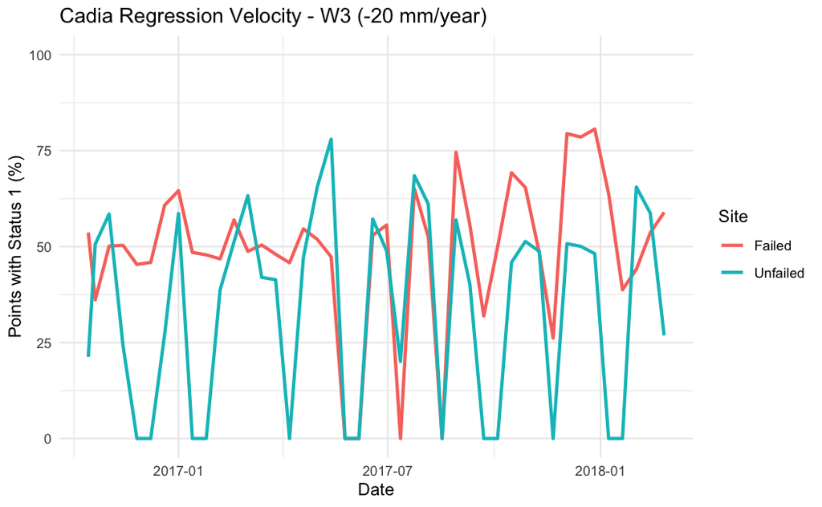

```r
compare_velocity_sites(
  cadia_F_vel_w3,
  cadia_S_vel_w3,
  cadia_F_vel_w3_thresh,
  cadia_S_vel_w3_thresh,
  threshold = -20,
  title_text =
    "Cadia Regression Velocity - W3 (-20 mm/year)"
)
```

#### 5.1.2 Status plots

```r
# Representative velocity threshold
velocity_threshold <- -20  # mm/year

# Cadia failed
cadia_F_vel_w3_status  <- make_status(cadia_F_vel_w3,  velocity_threshold)
cadia_F_vel_w5_status  <- make_status(cadia_F_vel_w5,  velocity_threshold)
cadia_F_vel_w10_status <- make_status(cadia_F_vel_w10, velocity_threshold)

# Cadia unfailed
cadia_S_vel_w3_status  <- make_status(cadia_S_vel_w3,  velocity_threshold)
cadia_S_vel_w5_status  <- make_status(cadia_S_vel_w5,  velocity_threshold)
cadia_S_vel_w10_status <- make_status(cadia_S_vel_w10, velocity_threshold)

# Peru failed
peru_F_vel_w3_status  <- make_status(peru_F_vel_w3,  velocity_threshold)
peru_F_vel_w5_status  <- make_status(peru_F_vel_w5,  velocity_threshold)
peru_F_vel_w10_status <- make_status(peru_F_vel_w10, velocity_threshold)

# Peru unfailed
peru_U_vel_w3_status  <- make_status(peru_U_vel_w3,  velocity_threshold)
peru_U_vel_w5_status  <- make_status(peru_U_vel_w5,  velocity_threshold)
peru_U_vel_w10_status <- make_status(peru_U_vel_w10, velocity_threshold)
```

```r
# Cadia
plot_status_comparison(
  cadia_F_vel_w3, cadia_S_vel_w3,
  cadia_F_vel_w3_status, cadia_S_vel_w3_status,
  "Cadia Regression Velocity - W3 (-20 mm/year)"
)

plot_status_comparison(
  cadia_F_vel_w5, cadia_S_vel_w5,
  cadia_F_vel_w5_status, cadia_S_vel_w5_status,
  "Cadia Regression Velocity - W5 (-20 mm/year)"
)

plot_status_comparison(
  cadia_F_vel_w10, cadia_S_vel_w10,
  cadia_F_vel_w10_status, cadia_S_vel_w10_status,
  "Cadia Regression Velocity - W10 (-20 mm/year)"
)

# Peru
plot_status_comparison(
  peru_F_vel_w3, peru_U_vel_w3,
  peru_F_vel_w3_status, peru_U_vel_w3_status,
  "Peru Regression Velocity - W3 (-20 mm/year)"
)

plot_status_comparison(
  peru_F_vel_w5, peru_U_vel_w5,
  peru_F_vel_w5_status, peru_U_vel_w5_status,
  "Peru Regression Velocity - W5 (-20 mm/year)"
)

plot_status_comparison(
  peru_F_vel_w10, peru_U_vel_w10,
  peru_F_vel_w10_status, peru_U_vel_w10_status,
  "Peru Regression Velocity - W10 (-20 mm/year)"
)
```

Final status thresholds:

```r
# Representative regression-velocity thresholds
cadia_vel_threshold <- -20   # mm/year
peru_vel_threshold  <- -15   # mm/year
```

```r
# -------------------------
# CADIA
# -------------------------

cadia_F_vel_w3_status <- make_status(
  cadia_F_vel_w3, cadia_vel_threshold
)

cadia_F_vel_w5_status <- make_status(
  cadia_F_vel_w5, cadia_vel_threshold
)

cadia_F_vel_w10_status <- make_status(
  cadia_F_vel_w10, cadia_vel_threshold
)

cadia_S_vel_w3_status <- make_status(
  cadia_S_vel_w3, cadia_vel_threshold
)

cadia_S_vel_w5_status <- make_status(
  cadia_S_vel_w5, cadia_vel_threshold
)

cadia_S_vel_w10_status <- make_status(
  cadia_S_vel_w10, cadia_vel_threshold
)


# -------------------------
# PERU
# -------------------------

peru_F_vel_w3_status <- make_status(
  peru_F_vel_w3, peru_vel_threshold
)

peru_F_vel_w5_status <- make_status(
  peru_F_vel_w5, peru_vel_threshold
)

peru_F_vel_w10_status <- make_status(
  peru_F_vel_w10, peru_vel_threshold
)

peru_U_vel_w3_status <- make_status(
  peru_U_vel_w3, peru_vel_threshold
)

peru_U_vel_w5_status <- make_status(
  peru_U_vel_w5, peru_vel_threshold
)

peru_U_vel_w10_status <- make_status(
  peru_U_vel_w10, peru_vel_threshold
)
```

```r
# W3
plot_status_comparison(
  peru_F_vel_w3, peru_U_vel_w3,
  peru_F_vel_w3_status, peru_U_vel_w3_status,
  "Peru Regression Velocity - W3 (-15 mm/year)"
)

# W5
plot_status_comparison(
  peru_F_vel_w5, peru_U_vel_w5,
  peru_F_vel_w5_status, peru_U_vel_w5_status,
  "Peru Regression Velocity - W5 (-15 mm/year)"
)

# W10
plot_status_comparison(
  peru_F_vel_w10, peru_U_vel_w10,
  peru_F_vel_w10_status, peru_U_vel_w10_status,
  "Peru Regression Velocity - W10 (-15 mm/year)"
)
```

#### 5.1.3 Exporting

```r
# converting function

make_velocity_export <- function(
  result,
  status,
  point_info
) {

  n_iters <- ncol(result$membership)

  export_df <- do.call(
    rbind,
    lapply(1:n_iters, function(iter) {

      data.frame(
        PointID = point_info$PointID,
        lon = point_info$lon,
        lat = point_info$lat,

        Date = as.Date(
          sub("^D_", "", result$iter_dates[iter]),
          format = "%Y%m%d"
        ),

        Cluster = result$membership[, iter],
        Velocity_mm_year = result$point_velocities[, iter],
        Status = status[, iter]
      )
    })
  )

  return(export_df)
}
```

```r
# Cadia failed
cadia_F_vel_w3_export <- make_velocity_export(
  cadia_F_vel_w3,
  cadia_F_vel_w3_status,
  cadia_info
)

cadia_F_vel_w5_export <- make_velocity_export(
  cadia_F_vel_w5,
  cadia_F_vel_w5_status,
  cadia_info
)

cadia_F_vel_w10_export <- make_velocity_export(
  cadia_F_vel_w10,
  cadia_F_vel_w10_status,
  cadia_info
)


# Cadia unfailed
cadia_S_vel_w3_export <- make_velocity_export(
  cadia_S_vel_w3,
  cadia_S_vel_w3_status,
  cadia_south_info
)

cadia_S_vel_w5_export <- make_velocity_export(
  cadia_S_vel_w5,
  cadia_S_vel_w5_status,
  cadia_south_info
)

cadia_S_vel_w10_export <- make_velocity_export(
  cadia_S_vel_w10,
  cadia_S_vel_w10_status,
  cadia_south_info
)


# Peru failed
peru_F_vel_w3_export <- make_velocity_export(
  peru_F_vel_w3,
  peru_F_vel_w3_status,
  peru_F_export_info
)

peru_F_vel_w5_export <- make_velocity_export(
  peru_F_vel_w5,
  peru_F_vel_w5_status,
  peru_F_export_info
)

peru_F_vel_w10_export <- make_velocity_export(
  peru_F_vel_w10,
  peru_F_vel_w10_status,
  peru_F_export_info
)


# Peru unfailed
peru_U_vel_w3_export <- make_velocity_export(
  peru_U_vel_w3,
  peru_U_vel_w3_status,
  peru_U_export_info
)

peru_U_vel_w5_export <- make_velocity_export(
  peru_U_vel_w5,
  peru_U_vel_w5_status,
  peru_U_export_info
)

peru_U_vel_w10_export <- make_velocity_export(
  peru_U_vel_w10,
  peru_U_vel_w10_status,
  peru_U_export_info
)
```

```r
write.csv(
  cadia_F_vel_w3_export,
  "../outputs/cadia_failed_sw_lr_w3_thresh20.csv",
  row.names = FALSE
)

write.csv(
  cadia_F_vel_w5_export,
  "../outputs/cadia_failed_sw_lr_w5_thresh20.csv",
  row.names = FALSE
)

write.csv(
  cadia_F_vel_w10_export,
  "../outputs/cadia_failed_sw_lr_w10_thresh20.csv",
  row.names = FALSE
)

write.csv(
  cadia_S_vel_w3_export,
  "../outputs/cadia_unfailed_sw_lr_w3_thresh20.csv",
  row.names = FALSE
)

write.csv(
  cadia_S_vel_w5_export,
  "../outputs/cadia_unfailed_sw_lr_w5_thresh20.csv",
  row.names = FALSE
)

write.csv(
  cadia_S_vel_w10_export,
  "../outputs/cadia_unfailed_sw_lr_w10_thresh20.csv",
  row.names = FALSE
)

write.csv(
  peru_F_vel_w3_export,
  "../outputs/peru_failed_sw_lr_w3_thresh15.csv",
  row.names = FALSE
)

write.csv(
  peru_F_vel_w5_export,
  "../outputs/peru_failed_sw_lr_w5_thresh15.csv",
  row.names = FALSE
)

write.csv(
  peru_F_vel_w10_export,
  "../outputs/peru_failed_sw_lr_w10_thresh15.csv",
  row.names = FALSE
)

write.csv(
  peru_U_vel_w3_export,
  "../outputs/peru_unfailed_sw_lr_w3_thresh15.csv",
  row.names = FALSE
)

write.csv(
  peru_U_vel_w5_export,
  "../outputs/peru_unfailed_sw_lr_w5_thresh15.csv",
  row.names = FALSE
)

write.csv(
  peru_U_vel_w10_export,
  "../outputs/peru_unfailed_sw_lr_w10_thresh15.csv",
  row.names = FALSE
)
```

Overall K=2 observations:

- Sliding-window results are sensitive to both window size and the deformation representation used.
- Larger windows generally produced more stable temporal classifications, with clearer failed/non-failed differentiation observed for Cadia than Peru.
- Threshold sensitivity also demonstrates that no single displacement or velocity magnitude consistently distinguishes failure-related behaviour across all case studies.

```r
# plots exporting
dir.create(
  "../outputs/sliding_window_plots",
  showWarnings = FALSE,
  recursive = TRUE
)

plot_width <- 1800
plot_height <- 1200
plot_res <- 180
```

Displacement version:

```r
# Displacement threshold-sensitivity plots

# W3
png(
  "../outputs/sliding_window_plots/cadia_disp_threshold_sensitivity_w3.png",
  width = plot_width,
  height = plot_height,
  res = plot_res
)

print(
  plot_threshold_sensitivity(
    cadia_F_w3,
    cadia_F_w3_thresh,
    "Cadia (F) - W3 Displacement Threshold Sensitivity"
  )
)

dev.off()


# W5
png(
  "../outputs/sliding_window_plots/cadia_disp_threshold_sensitivity_w5.png",
  width = plot_width,
  height = plot_height,
  res = plot_res
)

print(
  plot_threshold_sensitivity(
    cadia_F_w5,
    cadia_F_w5_thresh,
    "Cadia (F) - W5 Displacement Threshold Sensitivity"
  )
)

dev.off()


# W10
png(
  "../outputs/sliding_window_plots/cadia_disp_threshold_sensitivity_w10.png",
  width = plot_width,
  height = plot_height,
  res = plot_res
)

print(
  plot_threshold_sensitivity(
    cadia_F_w10,
    cadia_F_w10_thresh,
    "Cadia (F) - W10 Displacement Threshold Sensitivity"
  )
)

dev.off()
```

```r
# W3
png(
  "../outputs/sliding_window_plots/cadia_unfailed_disp_threshold_sensitivity_w3.png",
  width = plot_width,
  height = plot_height,
  res = plot_res
)

print(
  plot_threshold_sensitivity(
    cadia_S_w3,
    cadia_S_w3_thresh,
    "Cadia (U) - W3 Displacement Threshold Sensitivity"
  )
)

dev.off()


# W5
png(
  "../outputs/sliding_window_plots/cadia_unfailed_disp_threshold_sensitivity_w5.png",
  width = plot_width,
  height = plot_height,
  res = plot_res
)

print(
  plot_threshold_sensitivity(
    cadia_S_w5,
    cadia_S_w5_thresh,
    "Cadia (U) - W5 Displacement Threshold Sensitivity"
  )
)

dev.off()


# W10
png(
  "../outputs/sliding_window_plots/cadia_unfailed_disp_threshold_sensitivity_w10.png",
  width = plot_width,
  height = plot_height,
  res = plot_res
)

print(
  plot_threshold_sensitivity(
    cadia_S_w10,
    cadia_S_w10_thresh,
    "Cadia (U) - W10 Displacement Threshold Sensitivity"
  )
)

dev.off()
```

```r
# -------------------------
# PERU FAILED
# -------------------------

png(
  "../outputs/sliding_window_plots/peru_failed_disp_threshold_sensitivity_w3.png",
  width = plot_width,
  height = plot_height,
  res = plot_res
)

print(
  plot_threshold_sensitivity(
    peru_F_w3,
    peru_F_w3_thresh,
    "Peru (F) - W3 Displacement Threshold Sensitivity"
  )
)

dev.off()


png(
  "../outputs/sliding_window_plots/peru_failed_disp_threshold_sensitivity_w5.png",
  width = plot_width,
  height = plot_height,
  res = plot_res
)

print(
  plot_threshold_sensitivity(
    peru_F_w5,
    peru_F_w5_thresh,
    "Peru (F) - W5 Displacement Threshold Sensitivity"
  )
)

dev.off()


png(
  "../outputs/sliding_window_plots/peru_failed_disp_threshold_sensitivity_w10.png",
  width = plot_width,
  height = plot_height,
  res = plot_res
)

print(
  plot_threshold_sensitivity(
    peru_F_w10,
    peru_F_w10_thresh,
    "Peru (F) - W10 Displacement Threshold Sensitivity"
  )
)

dev.off()


# -------------------------
# PERU UNFAILED
# -------------------------

png(
  "../outputs/sliding_window_plots/peru_unfailed_disp_threshold_sensitivity_w3.png",
  width = plot_width,
  height = plot_height,
  res = plot_res
)

print(
  plot_threshold_sensitivity(
    peru_U_w3,
    peru_U_w3_thresh,
    "Peru (U) - W3 Displacement Threshold Sensitivity"
  )
)

dev.off()


png(
  "../outputs/sliding_window_plots/peru_unfailed_disp_threshold_sensitivity_w5.png",
  width = plot_width,
  height = plot_height,
  res = plot_res
)

print(
  plot_threshold_sensitivity(
    peru_U_w5,
    peru_U_w5_thresh,
    "Peru (U) - W5 Displacement Threshold Sensitivity"
  )
)

dev.off()


png(
  "../outputs/sliding_window_plots/peru_unfailed_disp_threshold_sensitivity_w10.png",
  width = plot_width,
  height = plot_height,
  res = plot_res
)

print(
  plot_threshold_sensitivity(
    peru_U_w10,
    peru_U_w10_thresh,
    "Peru (U) - W10 Displacement Threshold Sensitivity"
  )
)

dev.off()
```

Regression velocity version:

```r
# Threshold sensitivity plots

# Cadia (F)

png(
  "../outputs/sliding_window_plots/cadia_vel_threshold_sensitivity_w3.png",
  width = plot_width,
  height = plot_height,
  res = plot_res
)

print(
  plot_velocity_threshold_sensitivity(
    cadia_F_vel_w3,
    cadia_F_vel_w3_thresh,
    "Cadia (F) - W3 Velocity Threshold Sensitivity"
  )
)

dev.off()


png(
  "../outputs/sliding_window_plots/cadia_vel_threshold_sensitivity_w5.png",
  width = plot_width,
  height = plot_height,
  res = plot_res
)

print(
  plot_velocity_threshold_sensitivity(
    cadia_F_vel_w5,
    cadia_F_vel_w5_thresh,
    "Cadia (F) - W5 Velocity Threshold Sensitivity"
  )
)

dev.off()


png(
  "../outputs/sliding_window_plots/cadia_vel_threshold_sensitivity_w10.png",
  width = plot_width,
  height = plot_height,
  res = plot_res
)

print(
  plot_velocity_threshold_sensitivity(
    cadia_F_vel_w10,
    cadia_F_vel_w10_thresh,
    "Cadia (F) - W10 Velocity Threshold Sensitivity"
  )
)

dev.off()
```

```r
# Cadia (U)

png(
  "../outputs/sliding_window_plots/cadia_unfailed_vel_threshold_sensitivity_w3.png",
  width = plot_width,
  height = plot_height,
  res = plot_res
)

print(
  plot_velocity_threshold_sensitivity(
    cadia_S_vel_w3,
    cadia_S_vel_w3_thresh,
    "Cadia (U) - W3 Velocity Threshold Sensitivity"
  )
)

dev.off()


png(
  "../outputs/sliding_window_plots/cadia_unfailed_vel_threshold_sensitivity_w5.png",
  width = plot_width,
  height = plot_height,
  res = plot_res
)

print(
  plot_velocity_threshold_sensitivity(
    cadia_S_vel_w5,
    cadia_S_vel_w5_thresh,
    "Cadia (U) - W5 Velocity Threshold Sensitivity"
  )
)

dev.off()


png(
  "../outputs/sliding_window_plots/cadia_unfailed_vel_threshold_sensitivity_w10.png",
  width = plot_width,
  height = plot_height,
  res = plot_res
)

print(
  plot_velocity_threshold_sensitivity(
    cadia_S_vel_w10,
    cadia_S_vel_w10_thresh,
    "Cadia (U) - W10 Velocity Threshold Sensitivity"
  )
)

dev.off()
```

```r
# Peru (both)

# -------------------------
# PERU FAILED
# -------------------------

png(
  "../outputs/sliding_window_plots/peru_failed_vel_threshold_sensitivity_w3.png",
  width = plot_width,
  height = plot_height,
  res = plot_res
)

print(
  plot_velocity_threshold_sensitivity(
    peru_F_vel_w3,
    peru_F_vel_w3_thresh,
    "Peru (F) - W3 Velocity Threshold Sensitivity"
  )
)

dev.off()


png(
  "../outputs/sliding_window_plots/peru_failed_vel_threshold_sensitivity_w5.png",
  width = plot_width,
  height = plot_height,
  res = plot_res
)

print(
  plot_velocity_threshold_sensitivity(
    peru_F_vel_w5,
    peru_F_vel_w5_thresh,
    "Peru (F) - W5 Velocity Threshold Sensitivity"
  )
)

dev.off()


png(
  "../outputs/sliding_window_plots/peru_failed_vel_threshold_sensitivity_w10.png",
  width = plot_width,
  height = plot_height,
  res = plot_res
)

print(
  plot_velocity_threshold_sensitivity(
    peru_F_vel_w10,
    peru_F_vel_w10_thresh,
    "Peru (F) - W10 Velocity Threshold Sensitivity"
  )
)

dev.off()


# -------------------------
# PERU UNFAILED
# -------------------------

png(
  "../outputs/sliding_window_plots/peru_unfailed_vel_threshold_sensitivity_w3.png",
  width = plot_width,
  height = plot_height,
  res = plot_res
)

print(
  plot_velocity_threshold_sensitivity(
    peru_U_vel_w3,
    peru_U_vel_w3_thresh,
    "Peru (U) - W3 Velocity Threshold Sensitivity"
  )
)

dev.off()


png(
  "../outputs/sliding_window_plots/peru_unfailed_vel_threshold_sensitivity_w5.png",
  width = plot_width,
  height = plot_height,
  res = plot_res
)

print(
  plot_velocity_threshold_sensitivity(
    peru_U_vel_w5,
    peru_U_vel_w5_thresh,
    "Peru (U) - W5 Velocity Threshold Sensitivity"
  )
)

dev.off()


png(
  "../outputs/sliding_window_plots/peru_unfailed_vel_threshold_sensitivity_w10.png",
  width = plot_width,
  height = plot_height,
  res = plot_res
)

print(
  plot_velocity_threshold_sensitivity(
    peru_U_vel_w10,
    peru_U_vel_w10_thresh,
    "Peru (U) - W10 Velocity Threshold Sensitivity"
  )
)

dev.off()
```

Status plots:

```r
# CADIA REGRESSION-BASED VELOCITY

p_cadia_vel_w3 <- plot_status_comparison(
  cadia_F_vel_w3,
  cadia_S_vel_w3,
  cadia_F_vel_w3_status,
  cadia_S_vel_w3_status,
  ""
)

p_cadia_vel_w5 <- plot_status_comparison(
  cadia_F_vel_w5,
  cadia_S_vel_w5,
  cadia_F_vel_w5_status,
  cadia_S_vel_w5_status,
  ""
)

p_cadia_vel_w10 <- plot_status_comparison(
  cadia_F_vel_w10,
  cadia_S_vel_w10,
  cadia_F_vel_w10_status,
  cadia_S_vel_w10_status,
  ""
)


# PERU REGRESSION-BASED VELOCITY

p_peru_vel_w3 <- plot_status_comparison(
  peru_F_vel_w3,
  peru_U_vel_w3,
  peru_F_vel_w3_status,
  peru_U_vel_w3_status,
  ""
) +
  theme(legend.position = "none")

p_peru_vel_w5 <- plot_status_comparison(
  peru_F_vel_w5,
  peru_U_vel_w5,
  peru_F_vel_w5_status,
  peru_U_vel_w5_status,
  ""
) +
  theme(legend.position = "none")

p_peru_vel_w10 <- plot_status_comparison(
  peru_F_vel_w10,
  peru_U_vel_w10,
  peru_F_vel_w10_status,
  peru_U_vel_w10_status,
  ""
) +
  theme(legend.position = "none")
```

```r
# Peru regression-based velocity plots
# Threshold = -15 mm/year

p_peru_vel_w3 <- plot_status_comparison(
  peru_F_vel_w3,
  peru_U_vel_w3,
  peru_F_vel_w3_status,
  peru_U_vel_w3_status,
  "Peru Regression Velocity - W3 (-15 mm/year)"
) +
  labs(
    title = "Peru Regression Velocity - W3 (-15 mm/year)"
  ) +
  theme(legend.position = "right")


p_peru_vel_w5 <- plot_status_comparison(
  peru_F_vel_w5,
  peru_U_vel_w5,
  peru_F_vel_w5_status,
  peru_U_vel_w5_status,
  "Peru Regression Velocity - W5 (-15 mm/year)"
) +
  labs(
    title = "Peru Regression Velocity - W5 (-15 mm/year)"
  ) +
  theme(legend.position = "right")


p_peru_vel_w10 <- plot_status_comparison(
  peru_F_vel_w10,
  peru_U_vel_w10,
  peru_F_vel_w10_status,
  peru_U_vel_w10_status,
  "Peru Regression Velocity - W10 (-15 mm/year)"
) +
  labs(
    title = "Peru Regression Velocity - W10 (-15 mm/year)"
  ) +
  theme(legend.position = "right")


# Re-export all three

ggsave(
  "../outputs/peru_velocity_status_w3.png",
  plot = p_peru_vel_w3,
  width = 10, height = 7, dpi = 300, bg = "white"
)

ggsave(
  "../outputs/peru_velocity_status_w5.png",
  plot = p_peru_vel_w5,
  width = 10, height = 7, dpi = 300, bg = "white"
)

ggsave(
  "../outputs/peru_velocity_status_w10.png",
  plot = p_peru_vel_w10,
  width = 10, height = 7, dpi = 300, bg = "white"
)
```

```r
# Cadia
ggsave(
  "../outputs/cadia_velocity_status_w3_2.png",
  p_cadia_vel_w3,
  width = 10, height = 7, dpi = 300
)

ggsave(
  "../outputs/cadia_velocity_status_w5_2.png",
  p_cadia_vel_w5,
  width = 10, height = 7, dpi = 300
)

ggsave(
  "../outputs/cadia_velocity_status_w10_2.png",
  p_cadia_vel_w10,
  width = 10, height = 7, dpi = 300
)

# Peru
ggsave(
  "../outputs/peru_velocity_status_w3.png",
  p_peru_vel_w3,
  width = 10, height = 7, dpi = 300
)

ggsave(
  "../outputs/peru_velocity_status_w5.png",
  p_peru_vel_w5,
  width = 10, height = 7, dpi = 300
)

ggsave(
  "../outputs/peru_velocity_status_w10.png",
  p_peru_vel_w10,
  width = 10, height = 7, dpi = 300
)
```

```r
# Consistent Cadia x-axis
cadia_axis <- scale_x_date(
  limits = as.Date(c("2016-10-01", "2018-03-01")),
  date_breaks = "3 months",
  date_labels = "%b %Y"
)

p_cadia_vel_w3 <- p_cadia_vel_w3 + cadia_axis
p_cadia_vel_w5 <- p_cadia_vel_w5 + cadia_axis
p_cadia_vel_w10 <- p_cadia_vel_w10 + cadia_axis


# Consistent Peru x-axis
peru_axis <- scale_x_date(
  limits = as.Date(c("2017-10-01", "2019-07-01")),
  date_breaks = "3 months",
  date_labels = "%b %Y"
)

p_peru_vel_w3 <- p_peru_vel_w3 + peru_axis
p_peru_vel_w5 <- p_peru_vel_w5 + peru_axis
p_peru_vel_w10 <- p_peru_vel_w10 + peru_axis
```

## 6. K = 3 Sliding Window

```r
# Cadia displacement: W3, W5 and W10

cadia_F_w3_k3 <- run_sliding_kmeans(
  cadia_D_filtered,
  window_size = 3,
  k = 3
)

cadia_F_w5_k3 <- run_sliding_kmeans(
  cadia_D_filtered,
  window_size = 5,
  k = 3
)

cadia_F_w10_k3 <- run_sliding_kmeans(
  cadia_D_filtered,
  window_size = 10,
  k = 3
)

cadia_S_w3_k3 <- run_sliding_kmeans(
  cadia_south_D_filtered,
  window_size = 3,
  k = 3
)

cadia_S_w5_k3 <- run_sliding_kmeans(
  cadia_south_D_filtered,
  window_size = 5,
  k = 3
)

cadia_S_w10_k3 <- run_sliding_kmeans(
  cadia_south_D_filtered,
  window_size = 10,
  k = 3
)
```

```r
# Cluster median ranges
range(cadia_F_w3_k3$cluster_medians, na.rm = TRUE)
range(cadia_F_w5_k3$cluster_medians, na.rm = TRUE)
range(cadia_F_w10_k3$cluster_medians, na.rm = TRUE)

range(cadia_S_w3_k3$cluster_medians, na.rm = TRUE)
range(cadia_S_w5_k3$cluster_medians, na.rm = TRUE)
range(cadia_S_w10_k3$cluster_medians, na.rm = TRUE)

# Silhouette summaries
summary(cadia_F_w5_k3$silhouette)
summary(cadia_F_w10_k3$silhouette)

summary(cadia_S_w5_k3$silhouette)
summary(cadia_S_w10_k3$silhouette)
```

```r
order_k3_medians <- function(result) {

  ordered <- t(apply(
    result$cluster_medians,
    1,
    sort
  ))

  colnames(ordered) <- c(
    "Higher",
    "Moderate",
    "Lower"
  )

  ordered
}
```

```r
F_w3_medians <- order_k3_medians(cadia_F_w3_k3)
F_w5_medians <- order_k3_medians(cadia_F_w5_k3)
F_w10_medians <- order_k3_medians(cadia_F_w10_k3)
```

```r
F_w3_med <- order_k3_medians(cadia_F_w3_k3)
F_w5_med <- order_k3_medians(cadia_F_w5_k3)
F_w10_med <- order_k3_medians(cadia_F_w10_k3)

S_w3_med <- order_k3_medians(cadia_S_w3_k3)
S_w5_med <- order_k3_medians(cadia_S_w5_k3)
S_w10_med <- order_k3_medians(cadia_S_w10_k3)
```

```r
# Failed
summary(F_w3_med)
summary(F_w5_med)
summary(F_w10_med)

# Unfailed
summary(S_w3_med)
summary(S_w5_med)
summary(S_w10_med)
```

```r
# Failed
apply(F_w3_med, 2, range, na.rm = TRUE)
apply(F_w5_med, 2, range, na.rm = TRUE)
apply(F_w10_med, 2, range, na.rm = TRUE)

# Unfailed
apply(S_w3_med, 2, range, na.rm = TRUE)
apply(S_w5_med, 2, range, na.rm = TRUE)
apply(S_w10_med, 2, range, na.rm = TRUE)
```

##### 6.1 Status

```r
get_k3_status <- function(result, moderate_threshold, higher_threshold) {

  status <- matrix(
    NA,
    nrow = nrow(result$membership),
    ncol = ncol(result$membership)
  )

  for (iter in 1:ncol(result$membership)) {

    medians <- result$cluster_medians[iter, ]

    cluster_status <- ifelse(
      medians <= higher_threshold, 3,
      ifelse(medians <= moderate_threshold, 2, 1)
    )

    status[, iter] <- cluster_status[
      result$membership[, iter]
    ]
  }

  return(status)
}
```

```r
# W3
cadia_F_w3_k3_status <- get_k3_status(
  cadia_F_w3_k3, -2, -4
)

cadia_S_w3_k3_status <- get_k3_status(
  cadia_S_w3_k3, -2, -4
)

# W5
cadia_F_w5_k3_status <- get_k3_status(
  cadia_F_w5_k3, -2, -5
)

cadia_S_w5_k3_status <- get_k3_status(
  cadia_S_w5_k3, -2, -5
)

# W10
cadia_F_w10_k3_status <- get_k3_status(
  cadia_F_w10_k3, -3, -6
)

cadia_S_w10_k3_status <- get_k3_status(
  cadia_S_w10_k3, -3, -6
)
```

###### 6.1.1 Plots

```r
plot_k3_status <- function(result, status, title_text) {

  # Percentage of points in each status at each window
  pct_lower <- colMeans(status == 1) * 100
  pct_moderate <- colMeans(status == 2) * 100
  pct_higher <- colMeans(status == 3) * 100

  dates <- as.Date(
    sub("^D_", "", result$iter_dates),
    "%Y%m%d"
  )

  plot_df <- data.frame(
    Date = rep(dates, 3),
    Percentage = c(
      pct_lower,
      pct_moderate,
      pct_higher
    ),
    Status = rep(
      c(
        "Lower deformation",
        "Moderate deformation",
        "Higher deformation"
      ),
      each = length(dates)
    )
  )

  ggplot(
    plot_df,
    aes(x = Date, y = Percentage, colour = Status)
  ) +
    geom_line(linewidth = 1) +
    labs(
      x = "Date",
      y = "Points (%)",
      colour = "Status",
      title = title_text
    ) +
    ylim(0, 100) +
    theme_minimal()
}
```

```r
plot_k3_status(
  cadia_F_w3_k3,
  cadia_F_w3_k3_status,
  "Cadia Failed - K=3 W3 (-2, -4 mm)"
)

plot_k3_status(
  cadia_F_w5_k3,
  cadia_F_w5_k3_status,
  "Cadia Failed - K=3 W5 (-2, -5 mm)"
)

plot_k3_status(
  cadia_F_w10_k3,
  cadia_F_w10_k3_status,
  "Cadia Failed - K=3 W10 (-3, -6 mm)"
)
```

```r
plot_k3_status(
  cadia_S_w3_k3,
  cadia_S_w3_k3_status,
  "Cadia Unfailed - K=3 W3 (-2, -4 mm)"
)

plot_k3_status(
  cadia_S_w5_k3,
  cadia_S_w5_k3_status,
  "Cadia Unfailed - K=3 W5 (-2, -5 mm)"
)

plot_k3_status(
  cadia_S_w10_k3,
  cadia_S_w10_k3_status,
  "Cadia Unfailed - K=3 W10 (-3, -6 mm)"
)
```

##### 6.2 Exporting

```r
make_k3_export <- function(result, status, metadata) {

  export <- data.frame(
    PointID = rep(metadata$PointID, times = ncol(status)),
    lon = rep(metadata$lon, times = ncol(status)),
    lat = rep(metadata$lat, times = ncol(status)),
    Date = rep(result$iter_dates, each = nrow(status)),
    Status = as.vector(status)
  )

  return(export)
}
```

```r
# convert

# Cadia Failed K=3

cadia_F_w3_k3_export <- make_sliding_export(
  cadia_F_w3_k3,
  cadia_F_w3_k3_status,
  cadia_info
)

cadia_F_w5_k3_export <- make_sliding_export(
  cadia_F_w5_k3,
  cadia_F_w5_k3_status,
  cadia_info
)

cadia_F_w10_k3_export <- make_sliding_export(
  cadia_F_w10_k3,
  cadia_F_w10_k3_status,
  cadia_info
)


# Cadia Unfailed K=3

cadia_S_w3_k3_export <- make_sliding_export(
  cadia_S_w3_k3,
  cadia_S_w3_k3_status,
  cadia_south_info
)

cadia_S_w5_k3_export <- make_sliding_export(
  cadia_S_w5_k3,
  cadia_S_w5_k3_status,
  cadia_south_info
)

cadia_S_w10_k3_export <- make_sliding_export(
  cadia_S_w10_k3,
  cadia_S_w10_k3_status,
  cadia_south_info
)
```

```r
head(cadia_F_w5_k3_export)
table(cadia_F_w5_k3_export$Status)

head(cadia_S_w5_k3_export)
table(cadia_S_w5_k3_export$Status)
```

```r
write.csv(
  cadia_F_w3_k3_export,
  "../outputs/clustering_csvs/cadia_F_k3_w3.csv",
  row.names = FALSE
)

write.csv(
  cadia_F_w5_k3_export,
  "../outputs/clustering_csvs/cadia_F_k3_w5.csv",
  row.names = FALSE
)

write.csv(
  cadia_F_w10_k3_export,
  "../outputs/clustering_csvs/cadia_F_k3_w10.csv",
  row.names = FALSE
)

write.csv(
  cadia_S_w3_k3_export,
  "../outputs/clustering_csvs/cadia_S_k3_w3.csv",
  row.names = FALSE
)

write.csv(
  cadia_S_w5_k3_export,
  "../outputs/clustering_csvs/cadia_S_k3_w5.csv",
  row.names = FALSE
)

write.csv(
  cadia_S_w10_k3_export,
  "../outputs/clustering_csvs/cadia_S_k3_w10.csv",
  row.names = FALSE
)
```

Export plots:

```r
# Failed

p_F_w3_k3 <- plot_k3_status(
  cadia_F_w3_k3,
  cadia_F_w3_k3_status,
  "Cadia Failed - K=3 W3 (-2, -4 mm)"
)

p_F_w5_k3 <- plot_k3_status(
  cadia_F_w5_k3,
  cadia_F_w5_k3_status,
  "Cadia Failed - K=3 W5 (-2, -5 mm)"
)

p_F_w10_k3 <- plot_k3_status(
  cadia_F_w10_k3,
  cadia_F_w10_k3_status,
  "Cadia Failed - K=3 W10 (-3, -6 mm)"
)


# Unfailed

p_S_w3_k3 <- plot_k3_status(
  cadia_S_w3_k3,
  cadia_S_w3_k3_status,
  "Cadia Unfailed - K=3 W3 (-2, -4 mm)"
)

p_S_w5_k3 <- plot_k3_status(
  cadia_S_w5_k3,
  cadia_S_w5_k3_status,
  "Cadia Unfailed - K=3 W5 (-2, -5 mm)"
)

p_S_w10_k3 <- plot_k3_status(
  cadia_S_w10_k3,
  cadia_S_w10_k3_status,
  "Cadia Unfailed - K=3 W10 (-3, -6 mm)"
)
```

```r
dir.create(
  "../outputs/sliding_window_plots/k3",
  recursive = TRUE,
  showWarnings = FALSE
)

ggsave("../outputs/sliding_window_plots/k3/cadia_F_k3_w3.png",
       p_F_w3_k3, width = 10, height = 7, dpi = 300, bg = "white")

ggsave("../outputs/sliding_window_plots/k3/cadia_F_k3_w5.png",
       p_F_w5_k3, width = 10, height = 7, dpi = 300, bg = "white")

ggsave("../outputs/sliding_window_plots/k3/cadia_F_k3_w10.png",
       p_F_w10_k3, width = 10, height = 7, dpi = 300, bg = "white")

ggsave("../outputs/sliding_window_plots/k3/cadia_S_k3_w3.png",
       p_S_w3_k3, width = 10, height = 7, dpi = 300, bg = "white")

ggsave("../outputs/sliding_window_plots/k3/cadia_S_k3_w5.png",
       p_S_w5_k3, width = 10, height = 7, dpi = 300, bg = "white")

ggsave("../outputs/sliding_window_plots/k3/cadia_S_k3_w10.png",
       p_S_w10_k3, width = 10, height = 7, dpi = 300, bg = "white")
```

Extra exporting:

```r
# FINAL FORMATTING FOR ALL STAGE 3 SLIDING WINDOW PLOTS

library(ggplot2)

# Consistent text formatting
final_theme <- theme_minimal(base_size = 15) +
  theme(
    plot.title = element_blank(),       # Remove individual plot titles
    axis.title = element_text(size = 16),
    axis.text = element_text(size = 14),
    legend.title = element_text(size = 14),
    legend.text = element_text(size = 14),
    legend.position = "right"
  )


# Consistent Cadia x-axis
cadia_axis <- scale_x_date(
  limits = as.Date(c("2016-10-01", "2018-03-01")),
  date_breaks = "3 months",
  date_labels = "%b %Y"
)


# Consistent Peru x-axis
peru_axis <- scale_x_date(
  limits = as.Date(c("2017-10-01", "2019-07-01")),
  date_breaks = "3 months",
  date_labels = "%b %Y"
)


# CADIA - Displacement
p_cadia_w3 <- p_cadia_w3 +
  cadia_axis + final_theme

p_cadia_w5 <- p_cadia_w5 +
  cadia_axis + final_theme

p_cadia_w10 <- p_cadia_w10 +
  cadia_axis + final_theme


# PERU - Displacement
p_peru_w3 <- p_peru_w3 +
  peru_axis + final_theme

p_peru_w5 <- p_peru_w5 +
  peru_axis + final_theme

p_peru_w10 <- p_peru_w10 +
  peru_axis + final_theme


# CADIA - Regression-based velocity
p_cadia_vel_w3 <- p_cadia_vel_w3 +
  cadia_axis + final_theme

p_cadia_vel_w5 <- p_cadia_vel_w5 +
  cadia_axis + final_theme

p_cadia_vel_w10 <- p_cadia_vel_w10 +
  cadia_axis + final_theme


# PERU - Regression-based velocity
p_peru_vel_w3 <- p_peru_vel_w3 +
  peru_axis + final_theme

p_peru_vel_w5 <- p_peru_vel_w5 +
  peru_axis + final_theme

p_peru_vel_w10 <- p_peru_vel_w10 +
  peru_axis + final_theme
```

```r
# FINAL EXPORTS

plots_to_export <- list(

  # Cadia displacement
  cadia_displacement_w3  = p_cadia_w3,
  cadia_displacement_w5  = p_cadia_w5,
  cadia_displacement_w10 = p_cadia_w10,

  # Peru displacement
  peru_displacement_w3  = p_peru_w3,
  peru_displacement_w5  = p_peru_w5,
  peru_displacement_w10 = p_peru_w10,

  # Cadia velocity
  cadia_velocity_w3  = p_cadia_vel_w3,
  cadia_velocity_w5  = p_cadia_vel_w5,
  cadia_velocity_w10 = p_cadia_vel_w10,

  # Peru velocity
  peru_velocity_w3  = p_peru_vel_w3,
  peru_velocity_w5  = p_peru_vel_w5,
  peru_velocity_w10 = p_peru_vel_w10
)


# Create output folder
dir.create(
  "../outputs/stage3_final_plots",
  recursive = TRUE,
  showWarnings = FALSE
)


# Export all plots
for (plot_name in names(plots_to_export)) {

  ggsave(
    filename = paste0(
      "../outputs/stage3_final_plots/",
      plot_name,
      ".png"
    ),
    plot = plots_to_export[[plot_name]],
    width = 10,
    height = 7,
    dpi = 300,
    bg = "white"
  )
}
```

## 7. Silhouette Scores

Expanding Window Approach:

```r
expanding_silhouette_table <- data.frame(
  Site = c("Cadia", "Cadia", "Peru", "Peru"),
  Outcome = c("Failed", "Unfailed", "Failed", "Unfailed"),
  Mean_Silhouette = c(
    mean(silhouette_values, na.rm = TRUE),
    mean(silhouette_values_south, na.rm = TRUE),
    mean(silhouette_peru_F, na.rm = TRUE),
    mean(silhouette_peru_U, na.rm = TRUE)
  )
)

expanding_silhouette_table$Mean_Silhouette <-
  round(expanding_silhouette_table$Mean_Silhouette, 3)

expanding_silhouette_table
```

Sliding Window Approach:

```r
silhouette_table_k2 <- data.frame(
  Site = c("Cadia", "Cadia", "Peru", "Peru"),
  Outcome = c("Failed", "Unfailed", "Failed", "Unfailed"),

  W3 = c(
    mean(cadia_F_w3$silhouette, na.rm = TRUE),
    mean(cadia_S_w3$silhouette, na.rm = TRUE),
    mean(peru_F_w3$silhouette, na.rm = TRUE),
    mean(peru_U_w3$silhouette, na.rm = TRUE)
  ),

  W5 = c(
    mean(cadia_F_w5$silhouette, na.rm = TRUE),
    mean(cadia_S_w5$silhouette, na.rm = TRUE),
    mean(peru_F_w5$silhouette, na.rm = TRUE),
    mean(peru_U_w5$silhouette, na.rm = TRUE)
  ),

  W10 = c(
    mean(cadia_F_w10$silhouette, na.rm = TRUE),
    mean(cadia_S_w10$silhouette, na.rm = TRUE),
    mean(peru_F_w10$silhouette, na.rm = TRUE),
    mean(peru_U_w10$silhouette, na.rm = TRUE)
  )
)

silhouette_table_k2[, 3:5] <- round(
  silhouette_table_k2[, 3:5], 3
)

silhouette_table_k2
```

K = 3 comparison:

```r
silhouette_table_k3 <- data.frame(
  Outcome = c("Failed", "Unfailed"),

  W3 = c(
    mean(cadia_F_w3_k3$silhouette, na.rm = TRUE),
    mean(cadia_S_w3_k3$silhouette, na.rm = TRUE)
  ),

  W5 = c(
    mean(cadia_F_w5_k3$silhouette, na.rm = TRUE),
    mean(cadia_S_w5_k3$silhouette, na.rm = TRUE)
  ),

  W10 = c(
    mean(cadia_F_w10_k3$silhouette, na.rm = TRUE),
    mean(cadia_S_w10_k3$silhouette, na.rm = TRUE)
  )
)

silhouette_table_k3[, 2:4] <- round(
  silhouette_table_k3[, 2:4], 3
)

silhouette_table_k3
```

```r
velocity_silhouette_table <- data.frame(
  Site = rep(c(
    "Cadia Failed",
    "Cadia Unfailed",
    "Peru Failed",
    "Peru Unfailed"
  ), each = 3),

  Window = rep(c("W3", "W5", "W10"), times = 4),

  Mean_Silhouette = c(
    # Cadia Failed
    mean(cadia_F_vel_w3$silhouette, na.rm = TRUE),
    mean(cadia_F_vel_w5$silhouette, na.rm = TRUE),
    mean(cadia_F_vel_w10$silhouette, na.rm = TRUE),

    # Cadia Unfailed (South)
    mean(cadia_S_vel_w3$silhouette, na.rm = TRUE),
    mean(cadia_S_vel_w5$silhouette, na.rm = TRUE),
    mean(cadia_S_vel_w10$silhouette, na.rm = TRUE),

    # Peru Failed
    mean(peru_F_vel_w3$silhouette, na.rm = TRUE),
    mean(peru_F_vel_w5$silhouette, na.rm = TRUE),
    mean(peru_F_vel_w10$silhouette, na.rm = TRUE),

    # Peru Unfailed
    mean(peru_U_vel_w3$silhouette, na.rm = TRUE),
    mean(peru_U_vel_w5$silhouette, na.rm = TRUE),
    mean(peru_U_vel_w10$silhouette, na.rm = TRUE)
  )
)

velocity_silhouette_table$Mean_Silhouette <-
  round(velocity_silhouette_table$Mean_Silhouette, 3)

View(velocity_silhouette_table)
```

```r
# Cadia
summary(cadia_F_vel_w3$silhouette)
summary(cadia_F_vel_w5$silhouette)
summary(cadia_F_vel_w10$silhouette)

summary(cadia_S_vel_w3$silhouette)
summary(cadia_S_vel_w5$silhouette)
summary(cadia_S_vel_w10$silhouette)

# Peru
summary(peru_F_vel_w3$silhouette)
summary(peru_F_vel_w5$silhouette)
summary(peru_F_vel_w10$silhouette)

summary(peru_U_vel_w3$silhouette)
summary(peru_U_vel_w5$silhouette)
summary(peru_U_vel_w10$silhouette)
```

```r
write.csv(
  expanding_silhouette_table,
  "../outputs/stage_3_expanding_silhouette_table.csv",
  row.names = FALSE
)
```

```r
# Convert displacement table to long format
displacement_long <- silhouette_table_k2 %>%
  pivot_longer(
    cols = c(W3, W5, W10),
    names_to = "Window",
    values_to = "Displacement"
  )

# Separate site and outcome in velocity table
velocity_long <- velocity_silhouette_table %>%
  mutate(
    Outcome = ifelse(
      grepl("Unfailed", Site),
      "Unfailed",
      "Failed"
    ),
    Site = ifelse(
      grepl("Cadia", Site),
      "Cadia",
      "Peru"
    )
  ) %>%
  rename(Velocity = Mean_Silhouette)

# Combine tables
combined_silhouette_table <- displacement_long %>%
  left_join(
    velocity_long,
    by = c("Site", "Outcome", "Window")
  ) %>%
  arrange(Site, Outcome, Window)

# Display
print(combined_silhouette_table)
```

```
# A tibble: 12 × 5
   Site  Outcome  Window Displacement Velocity
   <chr> <chr>    <chr>         <dbl>    <dbl>
 1 Cadia Failed   W10           0.274    0.53
 2 Cadia Failed   W3            0.374    0.493
 3 Cadia Failed   W5            0.297    0.502
 4 Cadia Unfailed W10           0.268    0.514
 5 Cadia Unfailed W3            0.372    0.493
 6 Cadia Unfailed W5            0.298    0.496
 7 Peru  Failed   W10           0.287    0.53
 8 Peru  Failed   W3            0.403    0.507
 9 Peru  Failed   W5            0.31     0.503
10 Peru  Unfailed W10           0.282    0.527
11 Peru  Unfailed W3            0.38     0.504
12 Peru  Unfailed W5            0.312    0.507
```

```r
# Export
write.csv(
  combined_silhouette_table,
  "../outputs/sliding_silhouette_table.csv",
  row.names = FALSE
)
```